# Exploratory Data Analysis and Logistic Regression

Rama Alassi & Ryan Rizk

2024-12-08

## Introduction

For this project we are using the forest fire data set. The data set contains various numerical features, and is separated into two groups representing different regions of Canada. These features would help us build a model to predict whether a forest with certain characteristics would experience fire. This report performs Exploratory Data Analysis (EDA), data preprocessing. Then we tried to fit multiple models such as logistic regression, LDA, QDA, KNN, SVM, decision tree, and other models. on the forest_fires_dataset.csv data set and assess their performance. And finally, we compared the performance of the models and analyse their output.

## Install and Load Libraries

```r
# Install and load required packages
if (!require("dplyr")) install.packages("dplyr", repos = "https://cloud.r-project.org/")
if (!require("ggplot2")) install.packages("ggplot2", repos = "https://cloud.r-project.org/")
if (!require("caret")) install.packages("caret", repos = "https://cloud.r-project.org/")
if (!require("glmnet")) install.packages("glmnet", repos = "https://cloud.r-project.org/")
if (!require("ggcorrplot")) install.packages("ggcorrplot", repos = "https://cloud.r-project.org/")
if (!require("nnet")) install.packages("nnet", repos = "https://cloud.r-project.org/")
if (!require("bloom"))install.packages("bloom", repos = "https://cloud.r-project.org/")
if (!require("pROC"))install.packages("pROC", repos = "https://cloud.r-project.org/")
if (!require("class"))install.packages("class", repos="https://cloud.r-project.org/")
if (!require("mice"))install.packages("class", repos="https://cloud.r-project.org/")
if (!require("broom"))install.packages("class", repos="https://cloud.r-project.org/")
if (!require("MASS"))install.packages("MASS", repos="https://cloud.r-project.org/")
if (!require("xgboost"))install.packages("xgboost", repos="https://cloud.r-project.org/")
if (!require("DALEX"))install.packages("DALEX", repos="https://cloud.r-project.org/")

library(DALEX)# logistic regression and PCA
library(reshape2)# for graphs
library(xgboost)# for tree
library(pROC) #Provides tools for analyzing the performance of classification models. It is used for the ROC curve
library(MASS) #LDA and QDA functions
library(broom) # It makes it easier to work with model outputs, such as coefficients, confidence intervals, and p-values.
library(mice) # handling missing values
library(dplyr) #data manipulation library.
library(ggplot2)# Provides visualization tools. Used for plotting.
library(caret) # data splitting
library(glmnet) #elastic net regularization
library(ggcorrplot) # A package for visualizing correlation matrices
library(nnet) #fitting neural networks


# load the dataset, ensuring the first row becomes column names
data <- read.csv("C:/Users/admin/Desktop/forest_fires_dataset.csv", stringsAsFactors = FALSE, header = TRUE)
```

We installed all the packages that allows us to analyse the data and build different models.

## Data Preparation

```r
print(data[1,])
```

```
##   Cordillera     X  X.1         X.2 X.3 X.4   X.5  X.6 X.7 X.8 X.9 X.10 X.11
## 1        day month year Temperature  RH  Ws Rain  FFMC DMC  DC ISI  BUI  FWI
##        X.12
## 1 Classes
```

```r
# Remove the first row
data <- data[-1, ]

# Trim space from column names
colnames(data) <- trimws(colnames(data))

# Check column count
if (ncol(data) < 14) stop("The dataset has fewer than 14 columns.")

# Numeric conversion with NA handling
data[,-14] <- lapply(data[,-14], function(col) {
  suppressWarnings(as.numeric(col))
})

# Create a logical index for rows without NAs in all but the 14th column
index <- apply(data[, -14], 1, function(x) !any(is.na(x)))

# Assign column names, ensure correct length
expected_colnames <- c("day", "month", "yeaSr", "Temperature", "RH", "Ws",
                       "Rain", "FFMC", "DMC", "DC", "ISI", "BUI", "FWI", "Classes")
if (length(expected_colnames) != ncol(data)) stop("Mismatch between data columns and expected column names.")
colnames(data) <- expected_colnames

# Replace missing or empty column names with default ones
if (any(is.na(colnames(data)) | colnames(data) == "")) {
  colnames(data)[is.na(colnames(data)) | colnames(data) == ""] <-
    paste0("X", seq_len(sum(is.na(colnames(data)) | colnames(data) == "")))
}

# Remove rows with all NA values
data <- data[!apply(is.na(data), 1, all), ]


# Display structure and summary of the cleaned dataset
cat("Dataset structure:\n", capture.output(str(data)), sep = "\n")
```

```
## Dataset structure:
##
## 'data.frame':    247 obs. of  14 variables:
##  $ day        : num  1 2 3 4 5 6 7 8 9 10 ...
##  $ month      : num  6 6 6 6 6 6 6 6 6 6 ...
##  $ yeaSr      : num  2012 2012 2012 2012 2012 ...
##  $ Temperature: num  29 29 26 25 27 31 33 30 25 28 ...
##  $ RH         : num  57 61 82 89 77 67 54 73 88 79 ...
##  $ Ws         : num  18 13 22 13 16 14 13 15 13 12 ...
##  $ Rain       : num  0 1.3 13.1 2.5 0 0 0 0 0.2 0 ...
##  $ FFMC       : num  65.7 64.4 47.1 28.6 64.8 82.6 88.2 86.6 52.9 73.2 ...
##  $ DMC        : num  3.4 4.1 2.5 1.3 3 5.8 9.9 12.1 7.9 9.5 ...
##  $ DC         : num  7.6 7.6 7.1 6.9 14.2 22.2 30.5 38.3 38.8 46.3 ...
##  $ ISI        : num  1.3 1 0.3 0 1.2 3.1 6.4 5.6 0.4 1.3 ...
##  $ BUI        : num  3.4 3.9 2.7 1.7 3.9 7 10.9 13.5 10.5 12.6 ...
##  $ FWI        : num  0.5 0.4 0.1 0 0.5 2.5 7.2 7.1 0.3 0.9 ...
##  $ Classes    : chr  "not fire   " "not fire   " "not fire   " "not fire   " ...
```

```r
cat("\nDataset summary:\n", capture.output(summary(data)), sep = "\n")
```

```
##
## Dataset summary:
##
##       day            month         yeaSr       Temperature          RH
##  Min.   : 1.00   Min.   :6.0   Min.   :2012   Min.   :22.00   Min.   :21.00
##  1st Qu.: 8.00   1st Qu.:7.0   1st Qu.:2012   1st Qu.:30.00   1st Qu.:52.00
##  Median :16.00   Median :7.5   Median :2012   Median :32.00   Median :63.00
##  Mean   :15.75   Mean   :7.5   Mean   :2012   Mean   :32.17   Mean   :61.94
##  3rd Qu.:23.00   3rd Qu.:8.0   3rd Qu.:2012   3rd Qu.:35.00   3rd Qu.:73.25
##  Max.   :31.00   Max.   :9.0   Max.   :2012   Max.   :42.00   Max.   :90.00
##  NA's   :3       NA's   :3     NA's   :3      NA's   :3       NA's   :3
##        Ws            Rain              FFMC            DMC
##  Min.   : 6.0   Min.   : 0.0000   Min.   :28.60   Min.   : 0.70
##  1st Qu.:14.0   1st Qu.: 0.0000   1st Qu.:72.08   1st Qu.: 5.80
##  Median :15.0   Median : 0.0000   Median :83.50   Median :11.30
##  Mean   :15.5   Mean   : 0.7607   Mean   :77.89   Mean   :14.67
##  3rd Qu.:17.0   3rd Qu.: 0.5000   3rd Qu.:88.30   3rd Qu.:20.75
##  Max.   :29.0   Max.   :16.8000   Max.   :96.00   Max.   :65.90
##  NA's   :3      NA's   :3         NA's   :3       NA's   :3
##        DC              ISI              BUI             FWI
##  Min.   :  6.90   Min.   : 0.000   Min.   : 1.10   Min.   : 0.000
##  1st Qu.: 12.35   1st Qu.: 1.400   1st Qu.: 6.00   1st Qu.: 0.700
##  Median : 33.10   Median : 3.500   Median :12.25   Median : 4.200
##  Mean   : 49.43   Mean   : 4.774   Mean   :16.66   Mean   : 7.035
##  3rd Qu.: 69.10   3rd Qu.: 7.300   3rd Qu.:22.52   3rd Qu.:11.450
##  Max.   :220.40   Max.   :19.000   Max.   :68.00   Max.   :31.100
##  NA's   :4        NA's   :3        NA's   :3       NA's   :4
##    Classes
##  Length:247
##  Class :character
##  Mode  :character
##
##
##
##
```

```r
print(dim(data))
```

```
## [1] 247  14
```

```r
# Check and handle missing values
data <- data.frame(lapply(data, function(column) {
  if (is.numeric(column)) {
    # Replace NA in numeric columns with the median (ignoring NAs)
    column[is.na(column)] <- median(column, na.rm = TRUE)
  }
  column
}))

# Create factor levels if necessary
if (is.null(levels(data$Classes))) {
  levels(data$Classes) <- c("not fire", "fire")
}

data <- data %>%
  mutate(Region = case_when(
    row_number() <= 122 ~ "Cordillera",
    TRUE ~ "Hudson Bay"
  )) %>%
  mutate(Region = ifelse(Region == "Cordillera", -1, 1))


# Display structure of the cleaned dataset
cat("Dataset structure:\n")
```

```
## Dataset structure:
```

```r
str(data)
```

```
## 'data.frame':    247 obs. of  15 variables:
##  $ day        : num  1 2 3 4 5 6 7 8 9 10 ...
##  $ month      : num  6 6 6 6 6 6 6 6 6 6 ...
##  $ yeaSr      : num  2012 2012 2012 2012 2012 ...
##  $ Temperature: num  29 29 26 25 27 31 33 30 25 28 ...
##  $ RH         : num  57 61 82 89 77 67 54 73 88 79 ...
##  $ Ws         : num  18 13 22 13 16 14 13 15 13 12 ...
##  $ Rain       : num  0 1.3 13.1 2.5 0 0 0 0 0.2 0 ...
##  $ FFMC       : num  65.7 64.4 47.1 28.6 64.8 82.6 88.2 86.6 52.9 73.2 ...
##  $ DMC        : num  3.4 4.1 2.5 1.3 3 5.8 9.9 12.1 7.9 9.5 ...
##  $ DC         : num  7.6 7.6 7.1 6.9 14.2 22.2 30.5 38.3 38.8 46.3 ...
##  $ ISI        : num  1.3 1 0.3 0 1.2 3.1 6.4 5.6 0.4 1.3 ...
##  $ BUI        : num  3.4 3.9 2.7 1.7 3.9 7 10.9 13.5 10.5 12.6 ...
##  $ FWI        : num  0.5 0.4 0.1 0 0.5 2.5 7.2 7.1 0.3 0.9 ...
##  $ Classes    : chr  "not fire   " "not fire   " "not fire   " "not fire   " ...
##   ..- attr(*, "levels")= chr [1:2] "not fire" "fire"
##  $ Region     : num  -1 -1 -1 -1 -1 -1 -1 -1 -1 -1 ...
```

```r
cat("\nDataset summary:\n")
```

```
##
## Dataset summary:
```

We added a new feature representing the region of each observation is in. At first, we added the the new qualitative feature with 2 values (“Cordillera”, “Hudson Bay”), the we encoded it to give it a quantitative value (-1 for”Cordillera”, 1 for “Hudson Bay”). The encoding would allow as to quantify and assess the relation of the forest region with the fire.

```r
# Count duplicates
set.seed(111)
duplicates <- duplicated(data)
cat("Duplicates before:", sum(duplicates), "\n")
```

```
## Duplicates before: 1
```

```r
data <- unique(data) # Remove duplicates
duplicates <- duplicated(data) # Verify removal
cat("Duplicates after:", sum(duplicates), "\n")
```

```
## Duplicates after: 0
```

```r
# Ensure 'Classes' column is consistent and convert to factor
data$Classes <- factor(trimws(data$Classes), levels = c("not fire", "fire"))

# Drop a column by its name
data <- data[, !colnames(data) %in% c("yeaSr")]
print(dim(data)) # To verify the reduction in the number of columns
```

```
## [1] 246  14
```

```r
# Separate untouched columns (13 and 14)
untouched_data <- data[, c(13, 14)]
standardized_data <- data[, -c(13, 14)]

# Identify numeric columns within the subset
numeric_columns <- sapply(standardized_data, is.numeric)

# Standardize only the numeric columns of the subset
standardized_data[numeric_columns] <- scale(standardized_data[numeric_columns])

# Combine standardized data with untouched columns
final_data <- cbind(standardized_data, untouched_data)

# Ensure 'Classes' is preserved and placed correctly
final_data$Classes <- data$Classes

# Update the main `data` object
data <- final_data

# Check for class imbalance
class_distribution <- table(data$Classes)
cat("Class Distribution:\n")
```

```
## Class Distribution:
```

```r
print(class_distribution)
```

```
##
## not fire     fire
##      106      137
```

```r
# View standardized data structure
str(data)
```

```
## 'data.frame':    246 obs. of  14 variables:
##  $ day        : num  -1.68 -1.57 -1.45 -1.34 -1.22 ...
##  $ month      : num  -1.35 -1.35 -1.35 -1.35 -1.35 ...
##  $ Temperature: num  -0.876 -0.876 -1.705 -1.981 -1.429 ...
##  $ RH         : num  -0.3337 -0.0639 1.3528 1.825 1.0155 ...
##  $ Ws         : num  0.893 -0.893 2.322 -0.893 0.179 ...
##  $ Rain       : num  -0.379 0.274 6.196 0.876 -0.379 ...
##  $ FFMC       : num  -0.856 -0.947 -2.158 -3.453 -0.919 ...
##  $ DMC        : num  -0.913 -0.856 -0.986 -1.083 -0.945 ...
##  $ DC         : num  -0.878 -0.878 -0.889 -0.893 -0.739 ...
##  $ ISI        : num  -0.833 -0.905 -1.073 -1.145 -0.857 ...
##  $ BUI        : num  -0.935 -0.899 -0.984 -1.055 -0.899 ...
##  $ FWI        : num  -0.878 -0.892 -0.932 -0.946 -0.878 ...
##  $ Classes    : Factor w/ 2 levels "not fire","fire": 1 1 1 1 1 2 2 2 1 1 ...
##  $ Region     : num  -1 -1 -1 -1 -1 -1 -1 -1 -1 -1 ...
```

Then we checked for duplicates to avoid miscalculations occurring due to repetition and ensure a unique data set, so we handled this problem using the unique() which ensure that every row in the data set is unique. for our data 1 duplicate is found and removed. For the response column, we used the trimws() function to remove extra spaces could be in the beginning or ending of the quantitative value to ensure proper comparison.We also deleted the “year” column since it is a constant variable (all observations are within 2012) since it has no effect on the response. And then we used the factor() function, which convert the values in the classes column to factor variables by specifying the column and the levels (different classes). This step allows the machine learning model to properly handling categorical values when applying different modeling functions like lm, and glim. After this we checked if a class imbalance exists and we found that the difference between the classes is not significant.

## Exploraty and Data Analysis

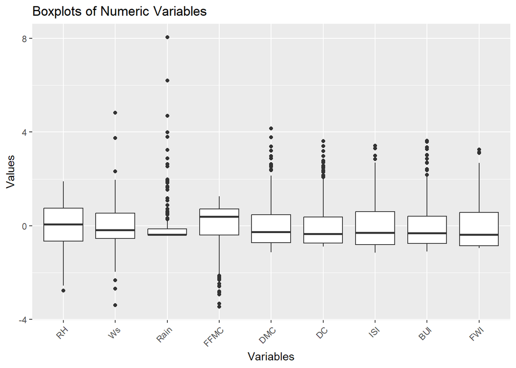

```r
# Visualize numeric variables
numeric_data <- data[,-c(1,2,3,14)]
ggplot(stack(numeric_data), aes(x = ind, y = values)) +
  geom_boxplot() +
  labs(title = "Boxplots of Numeric Variables", x = "Variables", y = "Values") +
  theme(axis.text.x = element_text(angle = 45, hjust = 1))
```

## Correlation Heatmap

```r
colSums(is.na(numeric_data))
```

```
##      RH      Ws    Rain    FFMC     DMC      DC     ISI     BUI     FWI Classes
##       0       0       0       0       0       0       0       0       0       3
```

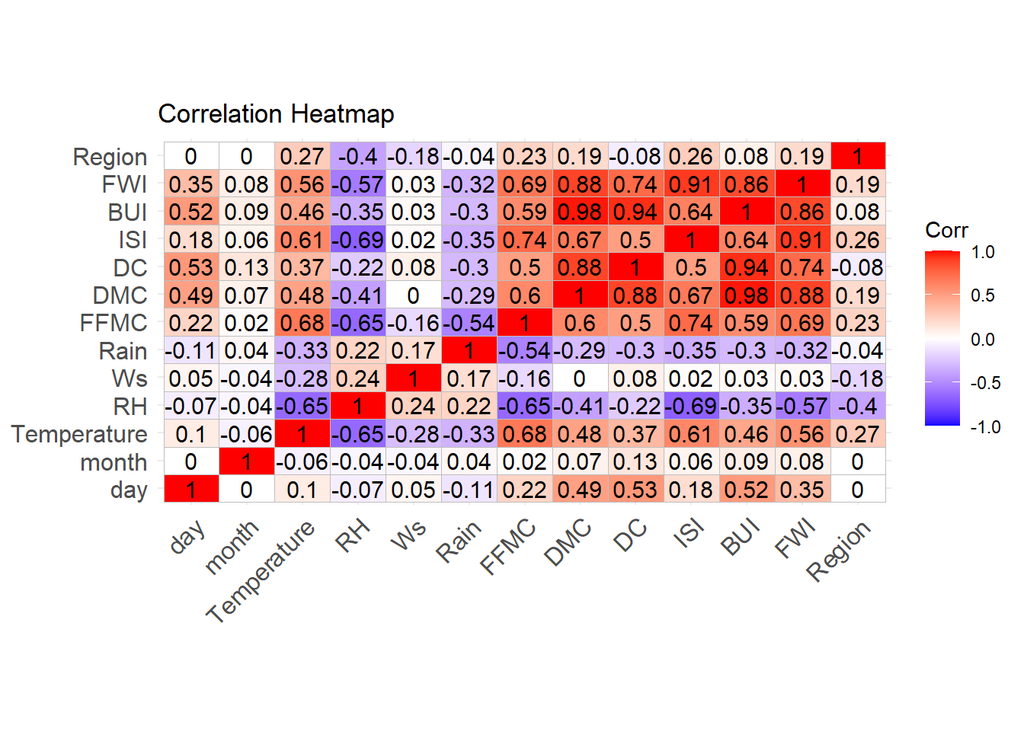

```r
# Convert column 14 to numeric (based on factor levels)
data[, 14] <- as.numeric(as.factor(data[, 14]))

# Recompute the correlation matrix with the modified data
numeric_data <- data[sapply(data, is.numeric)]
cor_matrix <- cor(numeric_data, use = "complete.obs")

# Plot the correlation heatmap
ggcorrplot(cor_matrix, lab = TRUE, title = "Correlation Heatmap") +
  theme(
    aspect.ratio = 0.5 # Adjust this to make the boxes more square-like (1 makes it equal height and width)
  )
```

This high correlation is expected due to the interdependencies among these variables. For example, the Build-Up Index (BUI) and the Fire Weather Index (FWI) are closely related, as the BUI is a component of the FWI system. Therefore, it is logical to see a robust correlation between these two indices.

The blue color shows a negative correlation between RH and all the other variables is except rain and Ws with a very light orange color and coefficient 0.22 and 0.24 respectively showing a weak relationship.

## Logistic Regresion

```
## Importance of components:
##                           PC1    PC2     PC3     PC4     PC5     PC6     PC7
## Standard deviation     2.4023 1.3290 1.01545 0.92181 0.80387 0.60869 0.49878
## Proportion of Variance 0.5246 0.1606 0.09374 0.07725 0.05875 0.03368 0.02262
## Cumulative Proportion  0.5246 0.6852 0.77897 0.85622 0.91497 0.94865 0.97127
##                            PC8     PC9    PC10    PC11
## Standard deviation     0.46020 0.27808 0.15057 0.06552
## Proportion of Variance 0.01925 0.00703 0.00206 0.00039
## Cumulative Proportion  0.99052 0.99755 0.99961 1.00000
```

```
##
## Features for PC 1 :
## [1] "FWI"  "DMC"  "BUI"  "ISI"  "FFMC"
##
## Features for PC 2 :
## [1] "Ws"          "Region"      "RH"          "DC"          "Temperature"
##
## Features for PC 3 :
## [1] "Rain"   "Region" "Ws"     "FFMC"   "RH"
##
## Features for PC 4 :
## [1] "Ws"   "ISI"  "Rain" "DC"   "BUI"
##
## Features for PC 5 :
## [1] "Region"      "Rain"        "Temperature" "RH"          "ISI"
##
## Features for PC 6 :
## [1] "Temperature" "ISI"         "Ws"          "FWI"         "DC"
##
## Features for PC 7 :
## [1] "RH"          "FFMC"        "ISI"         "Temperature" "FWI"
```

The results represent the output of Principal Component Analysis (PCA) on a dataset, with each principal component (PC) showing its importance based on standard deviation, proportion of variance explained, and cumulative variance. PC1 has the highest standard deviation of 2.4023 and explains 52.46% of the variance, indicating it captures the most significant variation in the data. The variance explained decreases with each subsequent component, with PC2 explaining 16.06% and so on. By PC6, the explained variance drops significantly, with each component contributing less than 5% to the total variance. The cumulative proportion shows that the first few components (PC1 to PC5) account for over 91% of the total variance, and by PC8, more than 99% of the variance is explained. This suggests that most of the variability in the dataset can be captured using just the first few principal components, making it a good candidate for dimensionality reduction while preserving significant information.

# Confusion Matrix

```r
# Step 7: Make predictions on the testing data
test_data_scaled <- test_data
test_data_scaled[predictor_cols] <- scale(test_data[predictor_cols], center = pca$center, scale = pca$scale)

# Project the test data onto the PCA space
test_data_pca <- predict(pca, newdata = test_data_scaled)
test_data_pca <- data.frame(test_data_pca[, 1:num_components])

# Make predictions using the final model
predicted_probs <- predict(final_model_pca, newdata = test_data_pca, type = "response")
predicted_classes <- ifelse(predicted_probs > 0.5, "Yes", "No")

# Create the confusion matrix
confusion_matrix <- table(test_data$Classes, predicted_classes)

# Print the confusion matrix
print(confusion_matrix)
```

```
##           predicted_classes
##            No Yes
##   not fire 19   2
##   fire      0  27
```

```r
# Make predictions using the final model (probabilities for class 1)
predicted_probs <- predict(final_model_pca, newdata = test_data_pca, type = "response")
```

True Negative (TN): 19 - The model correctly classified 19 instances as “not fire” when they were actually “not fire.” True Positive (TP): 27 - The model correctly classified 27 instances as “fire” when they were actually “fire.” False Positive (FP): 2 - The model misclassified 2 instances as “fire” when they were actually “not fire.” False Negative (FN): 0 - The model predicted all the “fire” instances correctly. The total number is 48 which represent testing sample size (20% of the data set).

# Different Metrics

To determine how good is the model performing, different metrics calculated and assessed quantifying its performance.

```r
set.seed(111)
# Extract values from the confusion matrix
TN <- confusion_matrix[1, 1]
FP <- confusion_matrix[1, 2]
FN <- confusion_matrix[2, 1]
TP <- confusion_matrix[2, 2]

# Calculate accuracy
accuracy <- (TP + TN) / sum(confusion_matrix)

# Calculate test error
test_error <- (FP + FN) / sum(confusion_matrix)

# Calculate recall
recall <- TP / (TP + FN)

# Calculate precision
precision <- TP / (TP + FP)

# Calculate F1 score
f1_score <- 2 * (precision * recall) / (precision + recall)

# Print results
print(paste("Accuracy:", accuracy))
```

```
## [1] "Accuracy: 0.958333333333333"
```

```r
print(paste("Test Error:", test_error))
```

```
## [1] "Test Error: 0.0416666666666667"
```

```r
print(paste("Recall:", recall))
```

```
## [1] "Recall: 1"
```

```r
print(paste("Precision:", precision))
```

```
## [1] "Precision: 0.931034482758621"
```

```r
print(paste("F1 Score:", f1_score))
```

```
## [1] "F1 Score: 0.964285714285714"
```

## KNN

```r
# Set seed for reproducibility
set.seed(111)
# Impute missing values in the training data
imp <- mice(train_data)
```

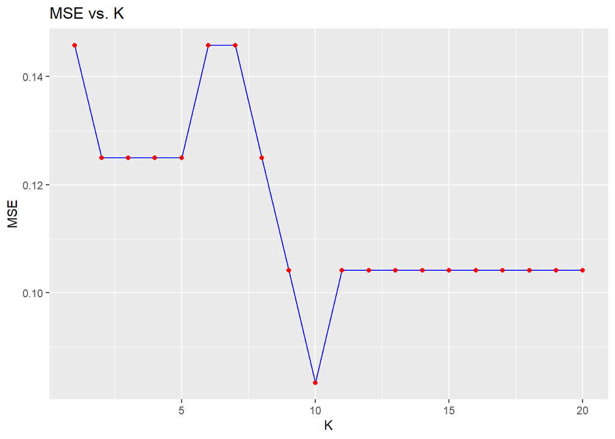

```r
train_data <- complete(imp, 1)
# Handle missing values
#train_data <- na.omit(train_data)
#test_data <- na.omit(test_data)

# Prepare feature and target data for training and testing
featureDataTrain <- train_data[, c("Temperature", "RH", "Ws", "Rain", "FFMC", "DMC", "ISI", "BUI", "FWI", "Region", "DC")]
targetDataTrain <- train_data$Class

featureDataTest <- test_data[, c("Temperature", "RH", "Ws", "Rain", "FFMC", "DMC", "ISI", "BUI", "FWI", "Region", "DC")]
targetDataTest <- test_data$Class


# Scale features
featureDataTrain <- scale(featureDataTrain)
featureDataTest <- scale(featureDataTest)

# KNN model and evaluation
k_values <- 1:20
mse_values <- numeric(length(k_values))

for (i in seq_along(k_values)) {
  k <- k_values[i]
  predictions <- knn(train = featureDataTrain, test = featureDataTest, cl = targetDataTrain, k = k)

  # Evaluate performance (consider other metrics like accuracy, precision, recall, F1-score)
  confusion_matrix <- table(predictions, targetDataTest)
  accuracy <- sum(diag(confusion_matrix)) / sum(confusion_matrix)
  mse_values[i] <- 1 - accuracy  # Calculate MSE from accuracy
}

# Plot the MSE curve
mse_data <- data.frame(k = k_values, MSE = mse_values)
ggplot(mse_data, aes(x = k, y = MSE)) +
  geom_line(color = "blue") +
  geom_point(color = "red") +
  labs(title = "MSE vs. K", x = "K", y = "MSE")
```

The for loop iterates over different K values to find the optimal number of neighbors. For each K, the model predicts the class labels for the test data based on the nearest neighbors in the training data. The model performance is evaluated using Mean Squared Error (MSE) for each k value. Finally, visualization of the relationship between K and MSE to identify the best-performing K value.The Graph represents that the lowest MSE when K=10.

```r
prediction10 <- knn(train = featureDataTrain, test = featureDataTest, cl = targetDataTrain, k = 10)


confusion_matrix1 <- table(prediction10, targetDataTest)
print(confusion_matrix1)
```

```
##             targetDataTest
## prediction10 not fire fire
##     not fire       16    1
##     fire            5   26
```

```r
# Extract probabilities for the positive class
knn_probabilities <- attr(prediction10, "prob")

# Adjust probabilities to always refer to the positive class
# Assuming the positive class is the second level of the factor
knn_probabilities <- ifelse(
  prediction10 == levels(train_data)[2],
  knn_probabilities,
  1 - knn_probabilities
)
```

We test the KNN model with K=10 using the testing data and computed the confusion matrix.

Even when we chose the K value that gives the lowest MSE, the model is doing errors.

# Different Metrics

```r
set.seed(111)
# Extract values from the confusion matrix
TN <- confusion_matrix1[1, 1]
FP <- confusion_matrix1[1, 2]
FN <- confusion_matrix1[2, 1]
TP <- confusion_matrix1[2, 2]

# Calculate accuracy
accuracy <- (TP + TN) / sum(confusion_matrix)

# Calculate test error
test_error <- (FP + FN) / sum(confusion_matrix)

# Calculate recall
recall <- TP / (TP + FN)

# Calculate precision
precision <- TP / (TP + FP)

# Calculate F1 score
f1_score <- 2 * (precision * recall) / (precision + recall)

# Print results
print(paste("Accuracy:", accuracy))
```

```
## [1] "Accuracy: 0.875"
```

```r
print(paste("Test Error:", test_error))
```

```
## [1] "Test Error: 0.125"
```

```r
print(paste("Recall:", recall))
```

```
## [1] "Recall: 0.838709677419355"
```

```r
print(paste("Precision:", precision))
```

```
## [1] "Precision: 0.962962962962963"
```

```r
print(paste("F1 Score:", f1_score))
```

```
## [1] "F1 Score: 0.896551724137931"
```

## LDA

```r
set.seed(111)
lda.fit <- lda(Classes ~ Temperature + RH + Ws + Rain + FFMC +
    DMC + ISI + BUI + FWI + Region + DC, family = binomial, data = train_data)

lda.fit
```

```
## Call:
## lda(Classes ~ Temperature + RH + Ws + Rain + FFMC + DMC + ISI +
##     BUI + FWI + Region + DC, data = train_data, family = binomial)
##
## Prior probabilities of groups:
##  not fire      fire
## 0.4292929 0.5707071
##
## Group means:
##          Temperature         RH          Ws       Rain       FFMC        DMC
## not fire  -0.5933114  0.5059424  0.03992948  0.4739761 -0.9068443 -0.6703939
## fire       0.4369921 -0.3982092 -0.03952033 -0.3307042  0.6793523  0.5251110
##                 ISI        BUI        FWI   Region         DC
## not fire -0.8465431 -0.6766334 -0.8223658 1.435294 -0.6000354
## fire      0.6788247  0.5254085  0.6511622 1.557522  0.4635292
##
## Coefficients of linear discriminants:
##                     LD1
## Temperature -0.10305873
## RH           0.67388993
## Ws          -0.11782712
## Rain         0.15470062
## FFMC         1.41535909
## DMC         -1.31363359
## ISI          0.75301653
## BUI          1.09038300
## FWI          0.63079593
## Region       0.19827533
## DC          -0.04702422
```

# LDA Performance

After the LDA model is trained, we need to test its performance on the unseen data. So, we predicted the class of each observation in the unseen data (test_data) used before.

```r
set.seed(111)
# testing the model
ldaPredictions <- predict(lda.fit, newdata = test_data)

# Predictions
ldaPredictions <- predict(lda.fit, newdata = test_data)
predictions_lda <- as.integer(ldaPredictions$class) - 1

# Verify Lengths
if (length(predictions_lda) != length(test_data$Classes)) {
    stop("Length of predictions and actual values do not match!")
}
```

# Confusion Matrix

```r
# Confusion Matrix
conf_matrix_lda <- table(Predicted = predictions_lda, Actual = test_data$Classes)
# Print Results
print(conf_matrix_lda)
```

```
##          Actual
## Predicted not fire fire
##         0       20    1
##         1        1   26
```

True Negative (TN): 20 - The model correctly classified 20 instances as “not fire” when they were actually “not fire.” True Positive (TP): 26 - The model correctly classified 26 instances as “fire” when they were actually “fire.” False Positive (FP): 1 - The model misclassified 1 instance as “fire” when it is actually “fire.” False Negative (FN): 1 - The model misclassified 1 instance as “not fire” when it is actually “fire.” The total number is 48 which represent testing sample size (20% of the data set).

# Different Metrics

```r
# Calculate Metrics
accuracy_lda <- sum(diag(conf_matrix_lda)) / sum(conf_matrix_lda)
test_error_lda <- 1 - accuracy_lda
recall_lda <- conf_matrix_lda[2, 2] / sum(conf_matrix_lda[2, ])
precision_lda <- conf_matrix_lda[2, 2] / sum(conf_matrix_lda[, 2])
f1_score_lda <- 2 * (precision_lda * recall_lda) / (precision_lda + recall_lda)

# Print Results
print(paste("Accuracy:", accuracy_lda))
```

```
## [1] "Accuracy: 0.958333333333333"
```

```r
print(paste("Test Error:", test_error_lda))
```

```
## [1] "Test Error: 0.0416666666666666"
```

```r
print(paste("Recall:", recall_lda))
```

```
## [1] "Recall: 0.962962962962963"
```

```r
print(paste("Precision:", precision_lda))
```

```
## [1] "Precision: 0.962962962962963"
```

```r
print(paste("F1 Score:", f1_score_lda))
```

```
## [1] "F1 Score: 0.962962962962963"
```

Accuracy (0.958): This means that 95.8% of the predictions are correct, both for fire and not fire cases. Test Error (0.0416): This indicates that 4.16% of the predictions are incorrect, meaning there are few misclassifications. Recall (0.962): This means that 96.2% of the actual fire cases are correctly predicted. Precision (0.962): This mean 96.2% of the “not fire” predictions are correctly predicted. F1 Score (0.962): The F1 score is also high, indicating that the model has a good balance between precision and recall.

The overall performance of the model is good. However other models performed better than KNN.

## QDA

```r
set.seed(111)
qda.fit <- qda(Classes ~ Temperature + RH + Ws + Rain + FFMC +
    DMC + ISI + BUI + FWI + Region + DC, family = binomial, data = train_data)
qda.fit
```

```
## Call:
## qda(Classes ~ Temperature + RH + Ws + Rain + FFMC + DMC + ISI +
##     BUI + FWI + Region + DC, data = train_data, family = binomial)
##
## Prior probabilities of groups:
##  not fire      fire
## 0.4292929 0.5707071
##
## Group means:
##          Temperature         RH          Ws       Rain       FFMC        DMC
## not fire  -0.5933114  0.5059424  0.03992948  0.4739761 -0.9068443 -0.6703939
## fire       0.4369921 -0.3982092 -0.03952033 -0.3307042  0.6793523  0.5251110
##                 ISI        BUI        FWI   Region         DC
## not fire -0.8465431 -0.6766334 -0.8223658 1.435294 -0.6000354
## fire      0.6788247  0.5254085  0.6511622 1.557522  0.4635292
```

```r
set.seed(111)
QDAPredictions <- predict(qda.fit, newdata = test_data)

# QDA Predictions
QDAPredictions <- predict(qda.fit, newdata = test_data)

# Convert predictions to binary class labels (0 or 1)
Predictions_QDA <- as.integer(QDAPredictions$class) - 1
```

# Confusion Matrix

```
##          Actual
## Predicted not fire fire
##         0       20    0
##         1        1   27
```

True Negative (TN): 20 - The model correctly classified 20 instances as “not fire” when they were actually “not fire.” True Positive (TP): 27 - The model correctly classified 27 instances as “fire” when they were actually “fire.” False Positive (FP): 1 - The model misclassified 1 instance as “fire” when it is actually “fire.” False Negative (FN): 0 - The model did not misclassify any instance as “not fire” when it is actually “fire.” The total number is 48 which represent testing sample size (20% of the data set).

# Different Metrics

```
## Accuracy: 0.9792
```

```
## Test Error: 0.0208
```

```
## Recall: 0.9643
```

```
## Precision: 1
```

```
## F1 Score: 0.9818
```

## Decision tree (pruned and unpruned)

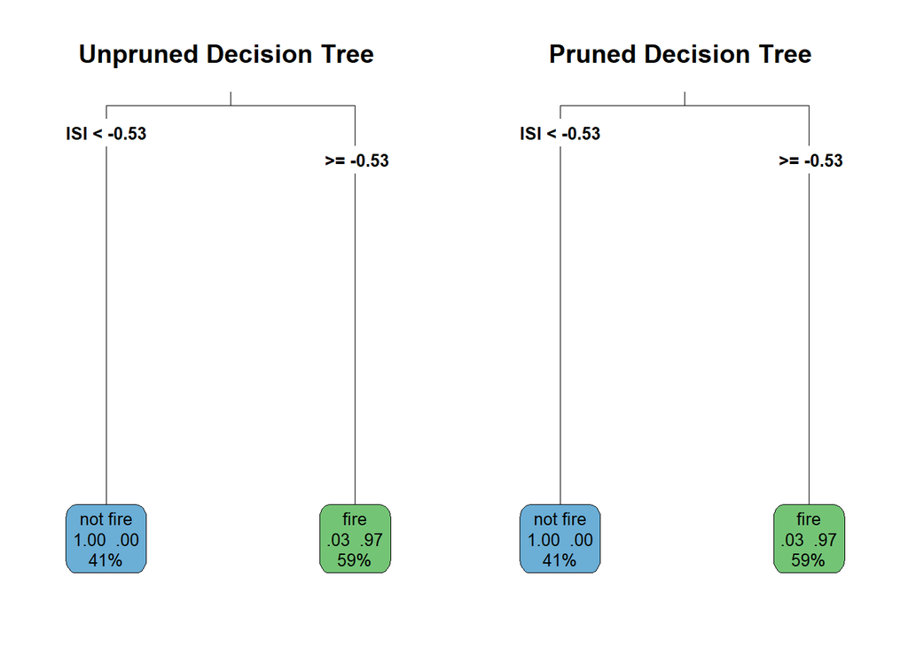

```
## Call:
## rpart(formula = Classes ~ Temperature + RH + Ws + Rain + FFMC +
##     DMC + ISI + BUI + FWI + Region + DC, data = train_data, method = "class")
##   n= 198
##
##          CP nsplit  rel error     xerror       xstd
## 1 0.9647059      0 1.00000000 1.00000000 0.08194023
## 2 0.0100000      1 0.03529412 0.07058824 0.02837754
##
## Variable importance
##  ISI FFMC  FWI   DC  BUI  DMC
##   20   20   18   15   14   14
##
## Node number 1: 198 observations,    complexity param=0.9647059
##   predicted class=fire      expected loss=0.4292929  P(node) =1
##     class counts:    85   113
##    probabilities: 0.429 0.571
##   left son=2 (82 obs) right son=3 (116 obs)
##   Primary splits:
##       ISI  < -0.5321914 to the left,  improve=91.17537, (0 missing)
##       FFMC < 0.1551434  to the left,  improve=89.29371, (0 missing)
##       FWI  < -0.6216101 to the left,  improve=78.19710, (0 missing)
##       DC   < -0.6651289 to the left,  improve=55.04072, (0 missing)
##       DMC  < -0.5272164 to the left,  improve=51.99516, (0 missing)
##   Surrogate splits:
##       FFMC < 0.144645   to the left,  agree=0.990, adj=0.976, (0 split)
##       FWI  < -0.6553873 to the left,  agree=0.944, adj=0.866, (0 split)
##       DC   < -0.6651289 to the left,  agree=0.889, adj=0.732, (0 split)
##       DMC  < -0.5353325 to the left,  agree=0.864, adj=0.671, (0 split)
##       BUI  < -0.6273793 to the left,  agree=0.864, adj=0.671, (0 split)
##
## Node number 2: 82 observations
##   predicted class=not fire  expected loss=0  P(node) =0.4141414
##     class counts:    82     0
##    probabilities: 1.000 0.000
##
## Node number 3: 116 observations
##   predicted class=fire      expected loss=0.02586207  P(node) =0.5858586
##     class counts:     3   113
##    probabilities: 0.026 0.974
```

```
## Call:
## rpart(formula = Classes ~ Temperature + RH + Ws + Rain + FFMC +
##     DMC + ISI + BUI + FWI + Region + DC, data = train_data, method = "class")
##   n= 198
##
##          CP nsplit  rel error     xerror       xstd
## 1 0.9647059      0 1.00000000 1.00000000 0.08194023
## 2 0.0100000      1 0.03529412 0.07058824 0.02837754
##
## Variable importance
##  ISI FFMC  FWI   DC  BUI  DMC
##   20   20   18   15   14   14
##
## Node number 1: 198 observations,    complexity param=0.9647059
##   predicted class=fire      expected loss=0.4292929  P(node) =1
##     class counts:    85   113
##    probabilities: 0.429 0.571
##   left son=2 (82 obs) right son=3 (116 obs)
##   Primary splits:
##       ISI  < -0.5321914 to the left,  improve=91.17537, (0 missing)
##       FFMC < 0.1551434  to the left,  improve=89.29371, (0 missing)
##       FWI  < -0.6216101 to the left,  improve=78.19710, (0 missing)
##       DC   < -0.6651289 to the left,  improve=55.04072, (0 missing)
##       DMC  < -0.5272164 to the left,  improve=51.99516, (0 missing)
##   Surrogate splits:
##       FFMC < 0.144645   to the left,  agree=0.990, adj=0.976, (0 split)
##       FWI  < -0.6553873 to the left,  agree=0.944, adj=0.866, (0 split)
##       DC   < -0.6651289 to the left,  agree=0.889, adj=0.732, (0 split)
##       DMC  < -0.5353325 to the left,  agree=0.864, adj=0.671, (0 split)
##       BUI  < -0.6273793 to the left,  agree=0.864, adj=0.671, (0 split)
##
## Node number 2: 82 observations
##   predicted class=not fire  expected loss=0  P(node) =0.4141414
##     class counts:    82     0
##    probabilities: 1.000 0.000
##
## Node number 3: 116 observations
##   predicted class=fire      expected loss=0.02586207  P(node) =0.5858586
##     class counts:     3   113
##    probabilities: 0.026 0.974
```

The tree predicts the class (fire or not fire) based on various environmental factors like Temperature, RH, Wind speed (Ws), etc. The data used for training has 198 observations, split into two terminal nodes (Node 2 and Node 3). Node 2 with 82 observations always predicts the class not fire. Node 3 with 116 observations predicts the class fire with 97.4% probability. The variable importance table ranks the predictors based on their contribution to splitting the data, ISI and FFMC are the most important. The “complexity parameter” (CP) table shows two potential splits, the tree chooses the split that minimizes the relative error. The first split was on ISI which gave the most improvement in classification accuracy. The surrogate splits are the backups when the primary variable is missing. This shows the hierarchical decision making and the key features that influence fire. The unpruned and pruned decision trees were generated using the rpart package. The trees split the data based on the variable that maximizes class separation. In this case the primary splitting variable in both trees is ISI (Initial Spread Index) with the first split at ISI < -0.53. This means ISI is the most important feature to distinguish between “fire” and “not fire”. The unpruned tree evaluates all possible splits and creates nodes until it minimizes impurity. The pruned tree applies cost-complexity pruning with cp = 0.01 and simplifies the tree structure while keeping the predictive power. Both trees show that when ISI < -0.53 the observations are classified as “not fire” (100% probability) and when ISI >= -0.53 the majority are classified as “fire” (97.4% probability). Surrogate splits like FFMC and FWI are used when ISI is not available to ensure robust decision making. Although other variables (e.g. FFMC, DMC, FWI) are considered for splits, ISI always provides the most improvement in node purity so it’s the dominant feature in the model.

```
##
## Call:
##  randomForest(formula = Classes ~ Temperature + RH + Ws + Rain +      FFMC + DMC + ISI + BUI + FWI + Region + DC, data = train_data,      method = "class", ntree = 500)
##                Type of random forest: classification
##                      Number of trees: 500
## No. of variables tried at each split: 3
##
##         OOB estimate of  error rate: 3.54%
## Confusion matrix:
##          not fire fire class.error
## not fire       81    4  0.04705882
## fire            3  110  0.02654867
```

```
## Confusion Matrix and Statistics
##
##           Reference
## Prediction not fire fire
##   not fire       21    0
##   fire            0   27
##
##                Accuracy : 1
##                  95% CI : (0.926, 1)
##     No Information Rate : 0.5625
##     P-Value [Acc > NIR] : 1.014e-12
##
##                   Kappa : 1
##
##  Mcnemar's Test P-Value : NA
##
##             Sensitivity : 1.0000
##             Specificity : 1.0000
##          Pos Pred Value : 1.0000
##          Neg Pred Value : 1.0000
##              Prevalence : 0.4375
##          Detection Rate : 0.4375
##    Detection Prevalence : 0.4375
##       Balanced Accuracy : 1.0000
##
##        'Positive' Class : not fire
##
```

Confusion matrix: True Negative (TN): 21 - The model correctly classified 21 instances as “not fire” when they were actually “not fire.” True Positive (TP): 27 - The model correctly classified 27 instances as “fire” when they were actually “fire.” False Positive (FP): 0 - The model misclassified 0 instance as “fire” when it is actually “fire.” False Negative (FN): 0 - The model did not misclassify any instance as “not fire” when it is actually “fire.” The total number is 48 which represent testing sample size (20% of the data set).

Different metrics: Accuracy (1) meaning the model predicted the correct label of the observations in the test set. Kappa(1) which is a measure to show how The predictions and the observations agrees and 1 means the model classified every instance correctly. The high accuracy and kappa values are explained by the confusion matrix where we do not have any wrong predictions.In addition, the model have very high sensitivity, specificity, precision,and balanced accuracy ( the average between sensitivity and specificity). The accuracy value falls in the confidence interval of 92.6%. Moreover, the No Information Rate (the proportion of the most frequent class in the dataset) is 0.5625 which indicates that the model would be accurate 56.25% of the time if it consistently predicted the majority class. The P-Value [Acc > NIR] : 1.014e-12 is extremely small showing that the accuracy is better than the NIR. The McNemar’s test depends on the wrong classifications. The model has achieved perfect predictions, and there are no disagreements between predicted and actual classes, so McNemar’s test cannot be performed.

## Tree (Random Forest)

```
##
## Call:
##  randomForest(formula = Classes ~ Temperature + RH + Ws + Rain +      FFMC + DMC + ISI + BUI + FWI + Region + DC, data = train_data,      method = "class", ntree = 500)
##                Type of random forest: classification
##                      Number of trees: 500
## No. of variables tried at each split: 3
##
##         OOB estimate of  error rate: 3.03%
## Confusion matrix:
##          not fire fire class.error
## not fire       81    4  0.04705882
## fire            2  111  0.01769912
```

```
## Confusion Matrix and Statistics
##
##           Reference
## Prediction not fire fire
##   not fire       21    0
##   fire            0   27
##
##                Accuracy : 1
##                  95% CI : (0.926, 1)
##     No Information Rate : 0.5625
##     P-Value [Acc > NIR] : 1.014e-12
##
##                   Kappa : 1
##
##  Mcnemar's Test P-Value : NA
##
##             Sensitivity : 1.0000
##             Specificity : 1.0000
##          Pos Pred Value : 1.0000
##          Neg Pred Value : 1.0000
##              Prevalence : 0.4375
##          Detection Rate : 0.4375
##    Detection Prevalence : 0.4375
##       Balanced Accuracy : 1.0000
##
##        'Positive' Class : not fire
##
```

## Tree (boosting)

```
##          Actual
## Predicted  0  1
##         0 20  0
##         1  1 27
```

[output not shown]

[output not shown]

[output not shown]

[output not shown]

[output not shown]

```
## [1] "Accuracy: 0.979166666666667"
```

XGBoost uses DMatrix objects to efficiently store and manipulate data. The xgb.DMatrix function creates DMatrix objects for both the training and test data. The model is trained using the metrics explained in the code, and then the predict function is used to make predictions on the test data. The model outputs probabilities for each data point, indicating the likelihood of the class being 1 (fire). To obtain binary predictions, a threshold of 0.5 is used.

## SVM

```
##           Actual
## Predicted  fire not fire
##   fire       25        0
##   not fire    2       21
```

```
##           Actual
## Predicted  fire not fire
##   fire       24        0
##   not fire    3       21
```

```
##           Actual
## Predicted  fire not fire
##   fire       26        1
##   not fire    1       20
```

We trained three SVM models using different kernel types: linear, polynomial, and radial basis function (RBF). 5-fold cross-validation for hyperparameter tuning by trainControl(). Then, regularization parameter C is tuned over 3 values for the linear kernel.The polynomial kernel model includes additional hyperparameters for the degree of the polynomial and scale factor, while the RBF kernel model tunes both the sigma (kernel width) and C parameters. Each model is trained using a common formula that specifies several predictor variables alongside the target variable.

Linear: True Negative (TN): 21 - The model correctly classified 21 instances as “not fire” when they were actually “not fire.” True Positive (TP): 25 - The model correctly classified 25 instances as “fire” when they were actually “fire.” False Positive (FP): 0 - The model misclassified 0 instances as “fire” when they were actually “not fire.” False Negative (FN): 2 - The model misclassified 2 instances as “not fire” when they were actually “fire.” The total number is 48, which represents the testing sample size (20% of the data set).

Polynomial: True Negative (TN): 21 - The model correctly classified 21 instances as “not fire” when they were actually “not fire.” True Positive (TP): 24 - The model correctly classified 24 instances as “fire” when they were actually “fire.” False Positive (FP): 0 - The model misclassified 0 instances as “fire” when they were actually “not fire.” False Negative (FN): 3 - The model misclassified 3 instances as “not fire” when they were actually “fire.” The total number is 48, which represents the testing sample size (20% of the data set).

RBF: True Negative (TN): 20 - The model correctly classified 20 instances as “not fire” when they were actually “not fire.” True Positive (TP): 26 - The model correctly classified 26 instances as “fire” when they were actually “fire.” False Positive (FP): 1 - The model misclassified 1 instance as “fire” when it was actually “not fire.” False Negative (FN): 1 - The model misclassified 1 instance as “not fire” when it was actually “fire.” The total number is 48, which represents the testing sample size (20% of the data set).

```
##
## Accuracy on Test Set:
```

```
## Linear Kernel SVM Accuracy:  0.9583333
```

```
## Polynomial Kernel SVM Accuracy:  0.9375
```

```
## RBF Kernel SVM Accuracy:  0.9583333
```

```
##
## Recall on Test Set:
```

```
## Linear Kernel SVM Recall:  0.9130435
```

```
## Polynomial Kernel SVM Recall:  0.875
```

```
## RBF Kernel SVM Recall:  0.952381
```

```
##
## Precision on Test Set:
```

```
## Linear Kernel SVM Precision:  1
```

```
## Polynomial Kernel SVM Precision:  1
```

```
## RBF Kernel SVM Precision:  0.952381
```

```
##
## F1-Score on Test Set:
```

```
## Linear Kernel SVM F1-Score:  0.9545455
```

```
## Polynomial Kernel SVM F1-Score:  0.9333333
```

```
## RBF Kernel SVM F1-Score:  0.952381
```

# Graphical Comparison

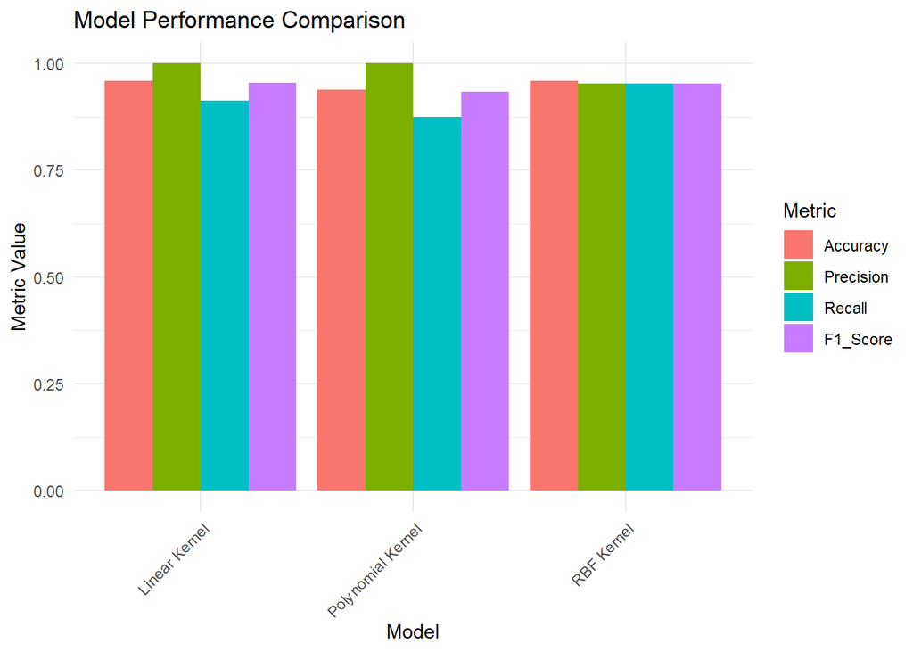

In terms of overall performance, the Linear Kernel SVM is slightly better due to its superior F1 score and perfect precision. However, if detecting as many “fire” instances as possible is the priority, the RBF Kernel SVM might be the better choice because of its higher recall.